# Анализ метрик

```python
import pandas as pd
import numpy as np
import matplotlib.pyplot as plt
```

```python
df = pd.read_csv('online_retail.csv')
df
```

|  | Invoice | Description | Quantity | InvoiceDate | Price | Customer ID | Amount |
| --- | --- | --- | --- | --- | --- | --- | --- |
| 0 | 493410 | This is a test product. | 5 | 2010-01-04 9:24:00 | 4,5 | 12346 | 22,5 |
| 1 | 493412 | This is a test product. | 5 | 2010-01-04 9:53:00 | 4,5 | 12346 | 22,5 |
| 2 | 493414 | RETRO SPOT MUG | 36 | 2010-01-04 10:28:00 | 2,55 | 14590 | 91,8 |
| 3 | 493414 | RETRO SPOT LARGE MILK JUG | 12 | 2010-01-04 10:28:00 | 4,25 | 14590 | 51 |
| 4 | 493414 | NEW ENGLAND CERAMIC CAKE SERVER | 2 | 2010-01-04 10:28:00 | 2,55 | 14590 | 5,1 |
| ... | ... | ... | ... | ... | ... | ... | ... |
| 164517 | 514212 | BAG 250g SWIRLY MARBLES | 2 | 2010-06-30 17:04:00 | 0,85 | 14882 | 1,7 |
| 164518 | 514212 | BLUE/CREAM STRIPE FRINGE HAMMOCK | 1 | 2010-06-30 17:04:00 | 7,95 | 14882 | 7,95 |
| 164519 | 514212 | OCEAN STRIPE HAMMOCK | 1 | 2010-06-30 17:04:00 | 7,95 | 14882 | 7,95 |
| 164520 | 514212 | RED/CREAM STRIPE FRINGE HAMMOCK | 1 | 2010-06-30 17:04:00 | 7,95 | 14882 | 7,95 |
| 164521 | 514212 | UNION STRIPE WITH FRINGE HAMMOCK | 1 | 2010-06-30 17:04:00 | 7,95 | 14882 | 7,95 |

164522 rows × 7 columns

```python
# удаляем дубликаты
df.drop_duplicates(inplace=True)

# переводим строку во временной формат
df['InvoiceDate'] = df['InvoiceDate'].apply(lambda date: pd.to_datetime(date, infer_datetime_format=True))

# выделяем дату
df['InvoiceDate'] = df['InvoiceDate'].dt.date

# выделяем квартал
df['Quarter'] = np.where(df['InvoiceDate']<=pd.to_datetime('2010-03-31').date(), 1, 2)

# выделяем месяц
df['Month'] = df['InvoiceDate'].apply(lambda date: date.month)

# выделяем номер недели
df['Week'] = df['InvoiceDate'].apply(lambda date: date.strftime('%U'))

# переведем строки в числа с плавающей точкой
df['Price'] = df['Price'].replace(',', '.', regex=True).astype('float')
df['Amount'] = df['Amount'].replace(',', '.', regex=True).astype('float')
```

```python
df
```

|  | Invoice | Description | Quantity | InvoiceDate | Price | Customer ID | Amount | Quarter | Month | Week |
| --- | --- | --- | --- | --- | --- | --- | --- | --- | --- | --- |
| 0 | 493410 | This is a test product. | 5 | 2010-01-04 | 4.50 | 12346 | 22.50 | 1 | 1 | 01 |
| 1 | 493412 | This is a test product. | 5 | 2010-01-04 | 4.50 | 12346 | 22.50 | 1 | 1 | 01 |
| 2 | 493414 | RETRO SPOT MUG | 36 | 2010-01-04 | 2.55 | 14590 | 91.80 | 1 | 1 | 01 |
| 3 | 493414 | RETRO SPOT LARGE MILK JUG | 12 | 2010-01-04 | 4.25 | 14590 | 51.00 | 1 | 1 | 01 |
| 4 | 493414 | NEW ENGLAND CERAMIC CAKE SERVER | 2 | 2010-01-04 | 2.55 | 14590 | 5.10 | 1 | 1 | 01 |
| ... | ... | ... | ... | ... | ... | ... | ... | ... | ... | ... |
| 164517 | 514212 | BAG 250g SWIRLY MARBLES | 2 | 2010-06-30 | 0.85 | 14882 | 1.70 | 2 | 6 | 26 |
| 164518 | 514212 | BLUE/CREAM STRIPE FRINGE HAMMOCK | 1 | 2010-06-30 | 7.95 | 14882 | 7.95 | 2 | 6 | 26 |
| 164519 | 514212 | OCEAN STRIPE HAMMOCK | 1 | 2010-06-30 | 7.95 | 14882 | 7.95 | 2 | 6 | 26 |
| 164520 | 514212 | RED/CREAM STRIPE FRINGE HAMMOCK | 1 | 2010-06-30 | 7.95 | 14882 | 7.95 | 2 | 6 | 26 |
| 164521 | 514212 | UNION STRIPE WITH FRINGE HAMMOCK | 1 | 2010-06-30 | 7.95 | 14882 | 7.95 | 2 | 6 | 26 |

161990 rows × 10 columns

```python
# пригодится для графиков
month_names = ["Янв", "Фев", "Март", "Апр", "Май", "Июнь"]
```

**1) Как изменилось количество уникальных покупателей за полгода?**

```python
# группируем таблицу по кварталам и подсчитываем количество уникальных клиентов в каждом
s = df.groupby('Quarter')['Customer ID'].nunique()
start = s[1]
end = s[2]

# подсчитываем рост
print(' Уникальных покупателей в первом квартале: ', round(start), '\n',
      'Уникальных покупателей во втором квартале: ', round(end), '\n',
      'Абсолютный прирост: ', round(end-start), '\n',
      'Относительный прирост: ', str(round((end-start)*100/start))+'%')
```

```
 Уникальных покупателей в первом квартале:  1805
 Уникальных покупателей во втором квартале:  2047
 Абсолютный прирост:  242
 Относительный прирост:  13%
```

```
 Уникальных покупателей в январе:  720
 Уникальных покупателей в июне:  1041
 Абсолютный прирост:  321
 Относительный прирост:  45%
```

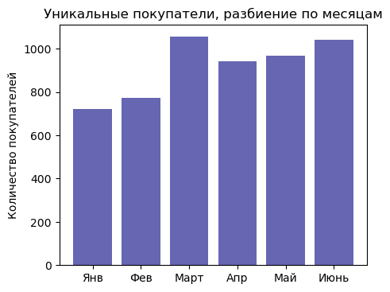

```python
# по месяцам
s = df.groupby('Month')['Customer ID'].nunique()
start = s[1]
end = s[6]

# подсчитываем рост
print(' Уникальных покупателей в январе: ', round(start), '\n',
      'Уникальных покупателей в июне: ', round(end), '\n',
      'Абсолютный прирост: ', round(end-start), '\n',
      'Относительный прирост: ',str(round((end-start)*100/start))+'%')

# строим график
plt.figure(figsize=(5, 4), dpi=100)
plt.bar(month_names, s.values, color=(0.4,0.4,0.7))
plt.ylabel("Количество покупателей")
plt.title("Уникальные покупатели, разбиение по месяцам")
plt.show()
```

```
 Предсказанных уникальных покупателей 4 января:  39
 Предсказанных уникальных покупателей 30 июня:  55
 Абсолютный прирост:  16
 Относительный прирост:  42%
```

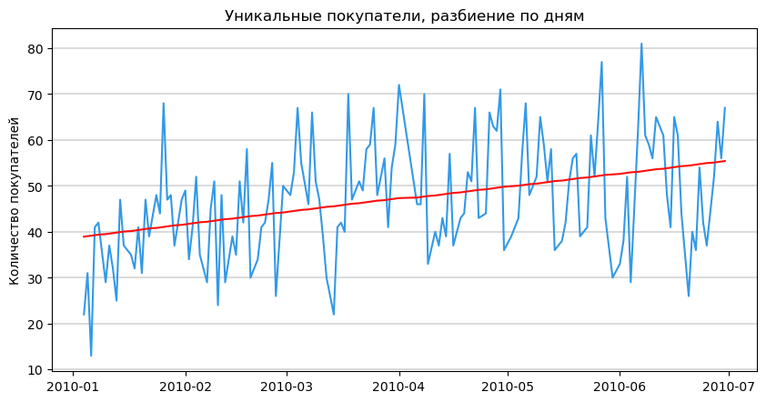

```python
# по дням
s = df.groupby('InvoiceDate')['Customer ID'].nunique()

# подсчитаем условное среднее количество уникальных клиентов
from sklearn.linear_model import LinearRegression
x = np.array([i for i in range(1, len(s) + 1)]).reshape(-1, 1)
y = np.array(s).reshape(-1, 1)
model = LinearRegression().fit(x, y)
y_pred = model.predict(x)

# рассчитаем предсказанный прирост с первого дня по последний день
start = y_pred[0][0]
end = y_pred[-1][0]
print(' Предсказанных уникальных покупателей 4 января: ', round(start), '\n',
      'Предсказанных уникальных покупателей 30 июня: ', round(end), '\n',
      'Абсолютный прирост: ', round(end-start), '\n',
      'Относительный прирост: ', str(round((end-start)*100/start))+'%')

# построим график
plt.figure(figsize=(10, 5), dpi=100)
plt.plot(s.index, s.values, color=(0.2,0.6,0.9))
plt.plot(s.index, y_pred, color=(1,0.05,0.05))
plt.grid(color='black', linestyle='-', linewidth = 0.2, axis='y')
plt.ylabel("Количество покупателей")
plt.title("Уникальные покупатели, разбиение по дням")
plt.show()
```

```python
df
```

|  | Invoice | Description | Quantity | InvoiceDate | Price | Customer ID | Amount | Quarter | Month | Week |
| --- | --- | --- | --- | --- | --- | --- | --- | --- | --- | --- |
| 0 | 493410 | This is a test product. | 5 | 2010-01-04 | 4.50 | 12346 | 22.50 | 1 | 1 | 01 |
| 1 | 493412 | This is a test product. | 5 | 2010-01-04 | 4.50 | 12346 | 22.50 | 1 | 1 | 01 |
| 2 | 493414 | RETRO SPOT MUG | 36 | 2010-01-04 | 2.55 | 14590 | 91.80 | 1 | 1 | 01 |
| 3 | 493414 | RETRO SPOT LARGE MILK JUG | 12 | 2010-01-04 | 4.25 | 14590 | 51.00 | 1 | 1 | 01 |
| 4 | 493414 | NEW ENGLAND CERAMIC CAKE SERVER | 2 | 2010-01-04 | 2.55 | 14590 | 5.10 | 1 | 1 | 01 |
| ... | ... | ... | ... | ... | ... | ... | ... | ... | ... | ... |
| 164517 | 514212 | BAG 250g SWIRLY MARBLES | 2 | 2010-06-30 | 0.85 | 14882 | 1.70 | 2 | 6 | 26 |
| 164518 | 514212 | BLUE/CREAM STRIPE FRINGE HAMMOCK | 1 | 2010-06-30 | 7.95 | 14882 | 7.95 | 2 | 6 | 26 |
| 164519 | 514212 | OCEAN STRIPE HAMMOCK | 1 | 2010-06-30 | 7.95 | 14882 | 7.95 | 2 | 6 | 26 |
| 164520 | 514212 | RED/CREAM STRIPE FRINGE HAMMOCK | 1 | 2010-06-30 | 7.95 | 14882 | 7.95 | 2 | 6 | 26 |
| 164521 | 514212 | UNION STRIPE WITH FRINGE HAMMOCK | 1 | 2010-06-30 | 7.95 | 14882 | 7.95 | 2 | 6 | 26 |

161990 rows × 10 columns

**2) На сколько процентов изменился средний чек во втором квартале по сравнению с первым?**

```
 Средний чек упал на 10% без очистки данных от выбросов
 Средний чек упал на 5% после очистки данных от очевидных крупных выбросов
 Средний чек упал на 8%, учитывая только данные в рамках трех стандартных отклонений
 Средний чек упал на 8%, учитывая только данные в рамках двух стандартных отклонений
```

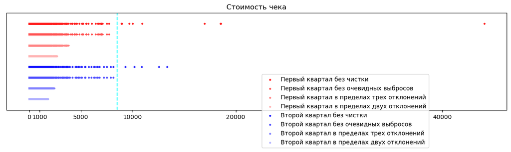

```python
# сгруппируем данные по кварталам и чекам
s = df.groupby(['Quarter', 'Invoice']).sum()['Amount']
df2 = pd.DataFrame(s).reset_index()

# функция, выделяющая данные в рамках n стандартных отклонений
def reject_outliers(data, number_of_stdv):
    return data[abs(data - np.mean(data)) < number_of_stdv * np.std(data)]

# список значений каждого чека в первом квартале
q1_orig = np.array(sorted(df2[df2['Quarter']==1]['Amount'].to_list()))
q1_limit = q1_orig[q1_orig<8500] # 8500 - порог, по которому будут определяться аномальные значения (бирюзовая линия на графике)
q1_three_stdv = reject_outliers(q1_orig, number_of_stdv=3) # убираем данные за пределами трех стандартных отклонений
q1_two_stdv = reject_outliers(q1_orig, number_of_stdv=2) # убираем данные за пределами двух стандартных отклонений

# во втором квартале
q2_orig = np.array(sorted(df2[df2['Quarter']==2]['Amount'].to_list()))
q2_limit = q2_orig[q2_orig<8500]
q2_three_stdv = reject_outliers(q2_orig, number_of_stdv=3)
q2_two_stdv = reject_outliers(q2_orig, number_of_stdv=2)

# средние значения каждого из списков
avg_q1_orig = np.mean(q1_orig)
avg_q1_limit = np.mean(q1_limit)
avg_q1_three_stdv = np.mean(q1_three_stdv)
avg_q1_two_stdv = np.mean(q1_two_stdv)
avg_q2_orig = np.mean(q2_orig)
avg_q2_limit = np.mean(q2_limit)
avg_q2_three_stdv = np.mean(q2_three_stdv)
avg_q2_two_stdv = np.mean(q2_two_stdv)

# подсчитываем рост среднего чека
print(' Средний чек упал на', str(round((avg_q2_orig - avg_q1_orig) * -100 / avg_q1_orig))+'% без очистки данных от выбросов')
print(' Средний чек упал на', str(round((avg_q2_limit - avg_q1_limit) * -100 / avg_q1_limit))+'% после очистки данных от очевидных крупных выбросов')
print(' Средний чек упал на', str(round((avg_q2_three_stdv - avg_q1_three_stdv) * -100 / avg_q1_three_stdv))+'%, учитывая только данные в рамках трех стандартных отклонений')
print(' Средний чек упал на', str(round((avg_q2_two_stdv - avg_q1_two_stdv) * -100 / avg_q1_two_stdv))+'%, учитывая только данные в рамках двух стандартных отклонений')

# строим график
plt.figure(figsize=(15, 3), dpi=100)

plt.scatter(q1_orig, [8 for i in range(len(q1_orig))], s=5, color=(1,0.1,0.1), label='Первый квартал без чистки')
plt.scatter(q1_limit, [7 for i in range(len(q1_limit))], s=5, color=(1,0.3,0.3), label='Первый квартал без очевидных выбросов')
plt.scatter(q1_three_stdv, [6 for i in range(len(q1_three_stdv))], s=5, color=(1,0.5,0.5), label='Первый квартал в пределах трех отклонений')
plt.scatter(q1_two_stdv, [5 for i in range(len(q1_two_stdv))], s=5, color=(1,0.7,0.7), label='Первый квартал в пределах двух отклонений')

plt.scatter(q2_orig, [4 for i in range(len(q2_orig))], s=5, color=(0.1,0.1,1), label='Второй квартал без чистки')
plt.scatter(q2_limit, [3 for i in range(len(q2_limit))], s=5, color=(0.3,0.3,1), label='Второй квартал без очевидных выбросов')
plt.scatter(q2_three_stdv, [2 for i in range(len(q2_three_stdv))], s=5, color=(0.5,0.5,1), label='Второй квартал в пределах трех отклонений')
plt.scatter(q2_two_stdv, [1 for i in range(len(q2_two_stdv))], s=5, color=(0.7,0.7,1), label='Второй квартал в пределах двух отклонений')

plt.vlines(x=8500, ymin=0, ymax=9, colors='aqua', linestyles='dashed')

plt.xticks([0, 1000, 5000, 10000, 20000, 40000])
plt.yticks([])
plt.legend(bbox_to_anchor=(0.85, 0.4))
plt.ylim(0, 9)
plt.title('Стоимость чека')
plt.show()
```

**3) Объясните с чем может быть связано падение ARPU?**

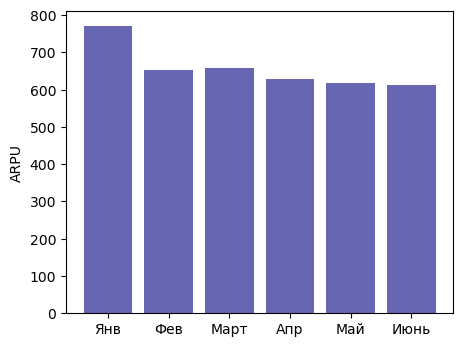

```python
# сгруппируем данные по кварталам и чекам
xf = df.groupby(['Month', 'Customer ID']).sum()['Amount']
s = pd.DataFrame(xf).groupby('Month').mean()['Amount']

# постоим график
plt.figure(figsize=(5, 4), dpi=100)
plt.bar(month_names, s.values, color=(0.4,0.4,0.7))
plt.ylabel("ARPU")
plt.show()
```

Из графика видно, что метрика ARPU c начала года упала. Этому может быть два объяснения, которые мы ниже проверим:

1. Поведение типичного нового покупателя каждого нового месяца хуже, чем поведение типичного нового покупателя месяца предыдущего

```python
# составим таблицу с ARPU каждого клиента по месяцам
xf = df.groupby(['Month', 'Customer ID']).sum()['Amount']
xf = xf.unstack().T
xf

# найдем месяц, в который пришел каждый из клиентов
first_month = pd.DataFrame(df.groupby('Customer ID').min()['Month'])

# и присоеденим его к таблице
xf = xf.join(first_month).rename_axis(columns="RPU").rename(columns={'Month':'First Month'})
xf

# расход каждого из клиентов в том месяце, котором он пришел
xf['Customer ID'] = xf.index
xf['First RPU'] = xf['Customer ID'].apply(lambda cust_id: xf.loc[int(cust_id)][int( xf.loc[int(cust_id)]['First Month'] )])
xf
```

| RPU Customer ID | 1 | 2 | 3 | 4 | 5 | 6 | First Month | Customer ID | First RPU |
| --- | --- | --- | --- | --- | --- | --- | --- | --- | --- |
| 12346 | 90.0 | NaN | 27.05 | NaN | NaN | 142.31 | 1 | 12346 | 90.00 |
| 12349 | NaN | NaN | NaN | 1068.52 | 200.00 | NaN | 4 | 12349 | 1068.52 |
| 12355 | NaN | NaN | NaN | NaN | 488.21 | NaN | 5 | 12355 | 488.21 |
| 12358 | NaN | NaN | NaN | NaN | NaN | 268.10 | 6 | 12358 | 268.10 |
| 12359 | NaN | NaN | 683.34 | NaN | NaN | 489.80 | 3 | 12359 | 683.34 |
| ... | ... | ... | ... | ... | ... | ... | ... | ... | ... |
| 18276 | NaN | NaN | NaN | 300.92 | NaN | NaN | 4 | 18276 | 300.92 |
| 18281 | NaN | NaN | NaN | NaN | 120.32 | NaN | 5 | 18281 | 120.32 |
| 18283 | NaN | 96.9 | 235.12 | NaN | NaN | NaN | 2 | 18283 | 96.90 |
| 18285 | NaN | 427.0 | NaN | NaN | NaN | NaN | 2 | 18285 | 427.00 |
| 18287 | NaN | NaN | NaN | NaN | 1071.61 | NaN | 5 | 18287 | 1071.61 |

2759 rows × 9 columns

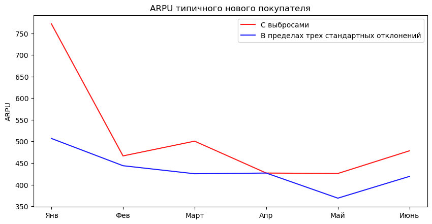

```python
# найдем средние расходы в первый месяц покупки каждого из клиентов
apru = xf.groupby('First Month').mean()['First RPU']

# очистим от выбросов за пределеами трех стандартных отклонений
apru_3_stdv = xf[xf['First RPU'] <= np.median(xf['First RPU']) + 3 * np.std(xf['First RPU'])].groupby('First Month').mean()['First RPU']

# построим график
plt.figure(figsize=(10, 5), dpi=100)
plt.plot(month_names, apru.values, label='С выбросами', color=(1,0.1,0.1))
plt.plot(month_names, apru_3_stdv.values, label='В пределах трех стандартных отклонений', color=(0.1,0.1,1))
plt.title('ARPU типичного нового покупателя')
plt.legend()
plt.ylabel("ARPU")
plt.show()
```

Как видно из графика, метрика ARPU для нового покупателя сильно упала с января по февраль, если учитывать выбросы. Эти выбросы и могут объяснить резкое падение общего ARPU с января по февраль (как видно на предыдущем графике). В январе было некоторое количество покупателей, которые принесли исключительно большую выручку магазину. Такой тип покупателя довольно типичен для начала года, поэтому падение ARPU можно объяснить сезонностью.

Однако, следует обратить внимание, что данная метрика, очищенная от выбросов, также имеет тенденцию к снижению, пусть и в значительно более умеренном темпе. Таким образом, первое объяснение достаточно достоверно.

1. Старые покупатели покупают хуже

```python
# сгрупируем средние месячные расходы по сегментам в зависимости от того, в какой месяц клиент сделал первую покупку
grouped_xf = xf.groupby(['First Month']).mean()
grouped_xf
```

| RPU First Month | 1 | 2 | 3 | 4 | 5 | 6 | Customer ID | First RPU |
| --- | --- | --- | --- | --- | --- | --- | --- | --- |
| 1 | 771.876656 | 1013.881382 | 1015.953588 | 890.946670 | 979.558204 | 916.515915 | 15284.822222 | 771.876656 |
| 2 | NaN | 466.489715 | 447.843403 | 623.907376 | 578.000882 | 527.248408 | 15311.250000 | 466.489715 |
| 3 | NaN | NaN | 500.622864 | 550.873437 | 495.993287 | 556.297908 | 15374.640489 | 500.622864 |
| 4 | NaN | NaN | NaN | 426.863997 | 331.527361 | 371.135676 | 15258.131285 | 426.863997 |
| 5 | NaN | NaN | NaN | NaN | 425.860067 | 336.806154 | 15473.430976 | 425.860067 |
| 6 | NaN | NaN | NaN | NaN | NaN | 478.336856 | 15428.735786 | 478.336856 |

```python
# то же самое, но очистим данные от выбросов за пределами трех стандартных отклонений
xxf = pd.DataFrame(xf)
for i in range(1, 7):
    med = np.median(xxf[xxf[i].notnull()][i]) # медиана
    stdev = np.std(xxf[xxf[1].notnull()][i]) # стандарное отклонение
    low = med - 3 * stdev # нижняя граница
    high = med + 3 * stdev # верхняя граница
    xxf = xxf[(xxf[i].isna())|((xxf[i] <= high)&(xxf[i] >= low))] # оставляем данные в пределах двух границ
grouped_xxf = xxf.groupby(['First Month']).mean() # группировка
grouped_xxf
```

[output not shown]

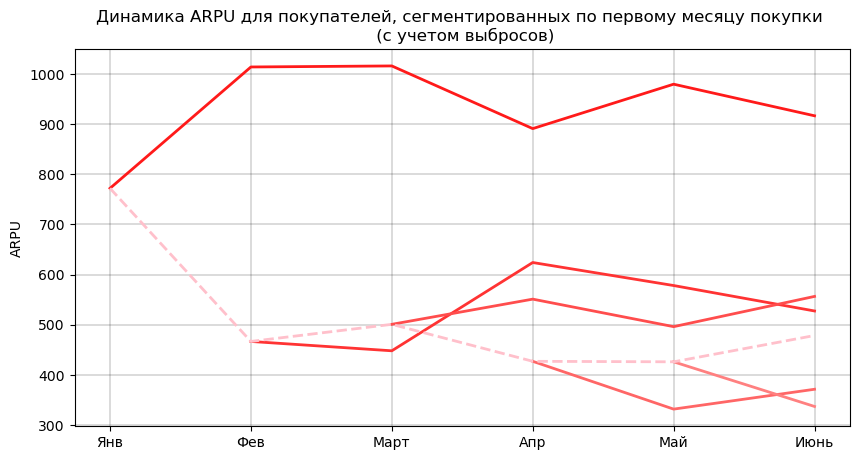

```python
# строим график

apru_1 = grouped_xf.loc[1, [1, 2, 3, 4, 5, 6]]
apru_2 = grouped_xf.loc[2, [1, 2, 3, 4, 5, 6]]
apru_3 = grouped_xf.loc[3, [1, 2, 3, 4, 5, 6]]
apru_4 = grouped_xf.loc[4, [1, 2, 3, 4, 5, 6]]
apru_5 = grouped_xf.loc[5, [1, 2, 3, 4, 5, 6]]
apru_6 = grouped_xf.loc[6, [1, 2, 3, 4, 5, 6]]
apru_first = grouped_xf['First RPU']

plt.figure(figsize=(10, 5), dpi=100)

plt.plot(month_names, apru_1.values, color=(1,0.1,0.1), linewidth = 2)
plt.plot(month_names, apru_2.values, color=(1,0.2,0.2), linewidth = 2)
plt.plot(month_names, apru_3.values, color=(1,0.3,0.3), linewidth = 2)
plt.plot(month_names, apru_4.values, color=(1,0.4,0.4), linewidth = 2)
plt.plot(month_names, apru_5.values, color=(1,0.5,0.5), linewidth = 2)
plt.plot(month_names, apru_6.values, color=(1,0.6,0.6), linewidth = 2)
plt.plot(month_names, apru_first.values, color='pink', linestyle='dashed', linewidth = 2)
plt.grid(color='black', linestyle='-', linewidth = 0.2)
plt.title('Динамика ARPU для покупателей, сегментированных по первому месяцу покупки \n (с учетом выбросов)')
plt.ylabel("ARPU")

plt.show()
```

Как видно из графика, ARPU покупателей, пришедших в первом квартале, с каждым месяцом растет и в дальнейшем стабилизируется на определенном уровне. Следовательно, данное объяснение падению общего ARPU можно отвергнуть.

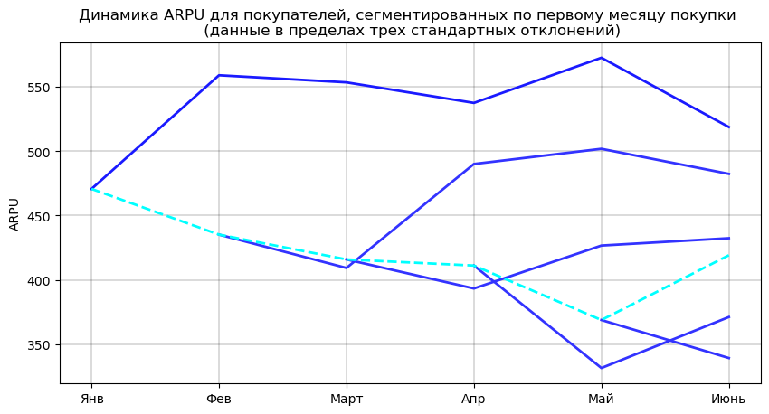

```python
# строим график, очистив данные от выбросов

apru_1_cleaned = grouped_xxf.loc[1, [1, 2, 3, 4, 5, 6]]
apru_2_cleaned  = grouped_xxf.loc[2, [1, 2, 3, 4, 5, 6]]
apru_3_cleaned  = grouped_xxf.loc[3, [1, 2, 3, 4, 5, 6]]
apru_4_cleaned  = grouped_xxf.loc[4, [1, 2, 3, 4, 5, 6]]
apru_5_cleaned  = grouped_xxf.loc[5, [1, 2, 3, 4, 5, 6]]
apru_6_cleaned  = grouped_xxf.loc[6, [1, 2, 3, 4, 5, 6]]
apru_first_cleaned  = grouped_xxf['First RPU']

plt.figure(figsize=(10, 5), dpi=100)

plt.plot(month_names, apru_1_cleaned.values, color=(0.1,0.1,1), linewidth = 2)
plt.plot(month_names, apru_2_cleaned.values, color=(0.2,0.2,1), linewidth = 2)
plt.plot(month_names, apru_3_cleaned.values, color=(0.2,0.2,1), linewidth = 2)
plt.plot(month_names, apru_4_cleaned.values, color=(0.2,0.2,1), linewidth = 2)
plt.plot(month_names, apru_5_cleaned.values, color=(0.2,0.2,1), linewidth = 2)
plt.plot(month_names, apru_6_cleaned.values, color=(0.2,0.2,1), linewidth = 2)
plt.plot(month_names, apru_first_cleaned.values, color='aqua', linestyle='dashed', linewidth = 2)
plt.grid(color='black', linestyle='-', linewidth = 0.2)
plt.title('Динамика ARPU для покупателей, сегментированных по первому месяцу покупки \n (данные в пределах трех стандартных отклонений)')
plt.ylabel("ARPU")

plt.show()
```

Схожая тенденция наблюдается, даже если мы очистим данные от выбросов.

**4) Как изменилось количество заказов на покупателя?**

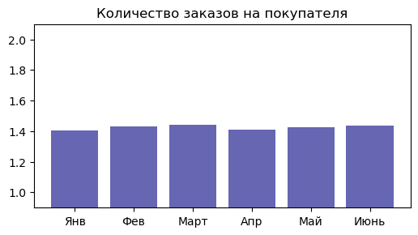

```python
# сколько заказов было у каждого из покупателей в каждый отдельный месяц
df4 = pd.DataFrame(df.groupby(['Month', 'Customer ID']).nunique()['Invoice']).reset_index()

# средннее количество заказов на покупателя каждый месяц
res = df4.groupby('Month').mean()['Invoice']

# построим график
plt.figure(figsize=(6, 3), dpi=100)
plt.bar(month_names, res.values, color=(0.4,0.4,0.7))
plt.title("Количество заказов на покупателя")
plt.ylim(0.9, 2.1)
plt.show()
```

Как видно из графика, количество заказов на покупателя колеблется крайне незначительно - около 1,4 заказов на покупателя.

**5) На сколько процентов изменилось количество товаров в заказе в июне по сравнению с мартом?**

```python
# средний размер заказа по месяцам
df5_1 = pd.DataFrame(df.groupby(['Month', 'Invoice']).sum()['Quantity']).reset_index()
s1 = df5_1.groupby('Month').mean()['Quantity']
s1
```

```
Month
1    365.994065
2    336.183544
3    329.373360
4    263.790068
5    279.518519
6    260.427522
Name: Quantity, dtype: float64
```

```python
# средний размер заказа по месяцам, данные очищенные от выбросов
df5_2 = df5_1[abs(df5_1['Quantity'] - np.median(df5_1['Quantity'])) < 3 * np.std(df5_1['Quantity'])]
s2 = df5_2.groupby('Month').mean()['Quantity']
s2
```

```
Month
1    248.220896
2    242.839383
3    254.338816
4    254.692540
5    243.708455
6    238.898123
Name: Quantity, dtype: float64
```

```python
march_1, june_1 = s1[3], s1[6]
march_2, june_2 = s2[3], s2[6]

print('Количество товаров в заказе упало на', str(round((june_1 - march_1) * -100 / march_1))+'%, учитывая выбросы')
print('Количество товаров в заказе упало на', str(round((june_2 - march_2) * -100 / march_2))+'%, учитывая только данные в пределах трех стандартных отклонений')
```

```
Количество товаров в заказе упало на 21%, учитывая выбросы
Количество товаров в заказе упало на 6%, учитывая только данные в пределах трех стандартных отклонений
```

**6) Предложите 1-2 идеи, как увеличить GMV в 3 квартале в 1,5 раза**

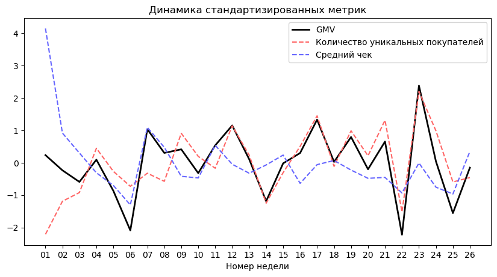

```python
GMV = np.array(df.groupby('Week').sum()['Amount']) # Выручка
N_of_uniq_cust = np.array(df.groupby('Week').nunique()['Customer ID']) # Количество уникальных покупателей
N_of_invoice = df.groupby('Week').nunique()['Invoice'] # Количество чеков
avg_invoice = GMV / np.array(N_of_invoice) # Средний чек

weeks = N_of_invoice.index

# стадтартизируем метрики, выразив их через собственные стандартные отклонения
GMV_2 = (GMV - np.mean(GMV)) / np.std(GMV)
N_of_uniq_cust_2 = (N_of_uniq_cust - np.mean(N_of_uniq_cust)) / np.std(N_of_uniq_cust)
avg_invoice_2 = (avg_invoice - np.mean(avg_invoice)) / np.std(avg_invoice)

# построим график
plt.figure(figsize=(10, 5), dpi=100)
plt.plot(weeks, GMV_2, color='black', label='GMV', linewidth = 2)
plt.plot(weeks, N_of_uniq_cust_2, color=(1,0.4,0.4), label='Количество уникальных покупателей', linestyle='dashed')
plt.plot(weeks, avg_invoice_2, color=(0.4,0.4,1), label='Средний чек', linestyle='dashed')
plt.legend()
plt.xlabel("Номер недели")
plt.title("Динамика стандартизированных метрик")
plt.show()
```

Как видно на графике, GMV сильнее коррелирует с количеством уникальных покупателей, нежели со средним чеком. Следовательно, для магизина, чтобы увеличить GMV, необходимо вкладывать больше ресурсов в привлечение новых и удержание старых покупателей, чем в повышение "эффективности" каждой отдельной покупки.

Из графика следует, что самое высокого значения метрика GMV достигла в первой недели июня. Предположим, что в третьем квартале удастся поддерживать среднее значение GMV на уровне этой недели. Достаточно ли будет этого, чтобы увеличить GMV в 1,5 раз?

```
GMV в третьем квартале в таком случае вырастет на 46% по сравнению со вторым кварталом.
```

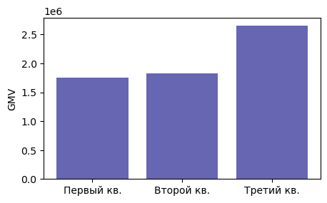

```python
# квартальная выручка
qgmv = df.groupby('Quarter').sum()['Amount']

# максимальная из исторических недельных выручек * 13 недель в квартале
qgmv[3] = max(GMV) * 13

print('GMV в третьем квартале в таком случае вырастет на ' + str(round((qgmv[3] - qgmv[2] ) * 100 / qgmv[2])) + '% по сравнению со вторым кварталом.')

# построим график
plt.figure(figsize=(5, 3), dpi=100)
plt.bar(['Первый кв.', 'Второй кв.', 'Третий кв.'], qgmv.values, color=(0.4,0.4,0.7))
plt.ylabel('GMV')
plt.show()
```

Необходимо проанализировать, что привлекло такое количество покупателей в эту неделю: какие акции и бонусные программы были активны, проанализировать типичную корзину (возможно, в ассортименте магазина появился какой-то товар, отсутствовавший в другие недели), посмотреть, как рекламные проекты были запущенны ранее. Если данный рост объясняется не сезонностью, а политикой магазина по привлечению покупателей, то необходимо утвердить такую политику в качестве ведущей.